# regression

```
   _____ _                 __     __  _____
  / ___/(_)___ ___  ____  / /__  /  |/  / /
  \__ \/ / __ `__ \/ __ \/ / _ \/ /|_/ / /
 ___/ / / / / / / / /_/ / /  __/ /  / / /___
/____/_/_/ /_/ /_/ .___/_/\___/_/  /_/_____/
                /_/

Type : Linear Regression
User : lmn
Analysis name: my-regression_Auto select best model_20200528
Model selection : Auto select best model
Date time : 2020-05-28 21:10:16.756538
Input data: boston
```

|  | crim | zn | indus | chas | nox | rm | age | dis | rad | tax | ptratio | black | lstat | medv |
| --- | --- | --- | --- | --- | --- | --- | --- | --- | --- | --- | --- | --- | --- | --- |
| 0 | 0.00632 | 18.0 | 2.31 | 0 | 0.538 | 6.575 | 65.2 | 4.0900 | 1 | 296 | 15.3 | 396.90 | 4.98 | 24.0 |
| 1 | 0.02731 | 0.0 | 7.07 | 0 | 0.469 | 6.421 | 78.9 | 4.9671 | 2 | 242 | 17.8 | 396.90 | 9.14 | 21.6 |
| 2 | 0.02729 | 0.0 | 7.07 | 0 | 0.469 | 7.185 | 61.1 | 4.9671 | 2 | 242 | 17.8 | 392.83 | 4.03 | 34.7 |
| 3 | 0.03237 | 0.0 | 2.18 | 0 | 0.458 | 6.998 | 45.8 | 6.0622 | 3 | 222 | 18.7 | 394.63 | 2.94 | 33.4 |
| 4 | 0.06905 | 0.0 | 2.18 | 0 | 0.458 | 7.147 | 54.2 | 6.0622 | 3 | 222 | 18.7 | 396.90 | 5.33 | 36.2 |

```
Data shape : (506, 14)
```

### Preprocessing and EDA

[interactive chart not shown]

## Comparing all Models

Comparing all models to evaluate performance is the recommended starting point for modeling once the setup is completed (unless you exactly know what kind of model you need, which is often not the case). This function trains all models in the model library and scores them using k-fold cross validation for metric evaluation. The output prints a score grid that shows average MAE, MSE, RMSE, R2, RMSLE and MAPE accross the folds (10 by default) of all the available models in the model library.

|  | Model | MAE | MSE | RMSE | R2 | RMSLE | MAPE |
| --- | --- | --- | --- | --- | --- | --- | --- |
| 0 | Gradient Boosting Regressor | 2.1994 | 8.117 | 2.8224 | 0.8901 | 0.135 | 0.1127 |
| 1 | CatBoost Regressor | 2.1062 | 8.6959 | 2.9082 | 0.8837 | 0.1294 | 0.1047 |
| 2 | Extreme Gradient Boosting | 2.2596 | 9.1466 | 2.984 | 0.877 | 0.1379 | 0.1148 |
| 3 | Extra Trees Regressor | 2.1316 | 9.1924 | 2.9853 | 0.8762 | 0.131 | 0.1062 |
| 4 | Random Forest | 2.2321 | 9.3955 | 3.0118 | 0.876 | 0.1385 | 0.1133 |
| 5 | Light Gradient Boosting Machine | 2.4492 | 12.325 | 3.4518 | 0.8359 | 0.1478 | 0.1197 |
| 6 | AdaBoost Regressor | 2.7124 | 13.1355 | 3.5792 | 0.8238 | 0.1741 | 0.148 |
| 7 | Decision Tree | 3.0144 | 18.3632 | 4.1867 | 0.7656 | 0.1977 | 0.1534 |
| 8 | Linear Regression | 3.3633 | 23.6146 | 4.7496 | 0.7004 | 0.2406 | 0.1636 |
| 9 | Least Angle Regression | 3.3633 | 23.6146 | 4.7496 | 0.7004 | 0.2406 | 0.1636 |
| 10 | Ridge Regression | 3.3511 | 23.7083 | 4.7578 | 0.6982 | 0.2541 | 0.1637 |
| 11 | Bayesian Ridge | 3.3512 | 24.2307 | 4.802 | 0.692 | 0.2638 | 0.164 |
| 12 | TheilSen Regressor | 3.2978 | 25.2598 | 4.8873 | 0.6826 | 0.2431 | 0.1548 |
| 13 | Random Sample Consensus | 3.2201 | 25.4178 | 4.8811 | 0.6808 | 0.2349 | 0.1495 |
| 14 | Elastic Net | 3.7317 | 29.0556 | 5.2731 | 0.6351 | 0.2733 | 0.1765 |
| 15 | Lasso Regression | 3.8032 | 30.1441 | 5.3721 | 0.6217 | 0.276 | 0.1794 |
| 16 | Huber Regressor | 3.5728 | 30.4283 | 5.3589 | 0.6187 | 0.2739 | 0.1697 |
| 17 | Orthogonal Matching Pursuit | 4.1597 | 33.8575 | 5.7258 | 0.5714 | 0.3062 | 0.2054 |
| 18 | K Neighbors Regressor | 4.5875 | 42.407 | 6.4106 | 0.4699 | 0.2524 | 0.2168 |
| 19 | Support Vector Machine | 5.3061 | 65.4909 | 7.9558 | 0.19 | 0.3086 | 0.2375 |
| 20 | Lasso Least Angle Regression | 6.5971 | 81.9992 | 9.003 | -0.047 | 0.3814 | 0.3532 |
| 21 | Passive Aggressive Regressor | 8.8184 | 133.069 | 10.9888 | -0.9404 | 0.5547 | 0.4806 |

```
Best suggested model based on best value for Gradient Boosting Regressor is R2
Selected Gradient Boosting Regressor based on R2
```

The score grid printed above highlights the highest performing metric for comparison purposes only. The grid by default is sorted using R2 (highest to lowest) which can be changed by passing sort parameter. For example compare_models(sort = 'RMSLE') will sort the grid by RMSLE (lower to higher since lower is better).

## Model

|  | MAE | MSE | RMSE | R2 | RMSLE | MAPE |
| --- | --- | --- | --- | --- | --- | --- |
| 0 | 2.6384 | 11.7271 | 3.4245 | 0.7847 | 0.2338 | 0.1907 |
| 1 | 2.4386 | 12.6024 | 3.5500 | 0.8612 | 0.1448 | 0.1117 |
| 2 | 2.8969 | 24.0786 | 4.9070 | 0.6299 | 0.1754 | 0.1247 |
| 3 | 2.5466 | 17.2709 | 4.1558 | 0.7671 | 0.1355 | 0.1034 |
| 4 | 2.2723 | 8.1148 | 2.8486 | 0.8801 | 0.1602 | 0.1235 |
| 5 | 3.2028 | 21.8871 | 4.6784 | 0.8122 | 0.1623 | 0.1319 |
| 6 | 2.0665 | 7.5124 | 2.7409 | 0.9001 | 0.1409 | 0.1134 |
| 7 | 1.5325 | 4.1399 | 2.0347 | 0.9525 | 0.0884 | 0.0730 |
| 8 | 2.7308 | 25.6747 | 5.0670 | 0.7486 | 0.1612 | 0.1024 |
| 9 | 1.7716 | 5.7604 | 2.4001 | 0.8986 | 0.1077 | 0.0911 |
| Mean | 2.4097 | 13.8768 | 3.5807 | 0.8235 | 0.1510 | 0.1166 |
| SD | 0.4853 | 7.4805 | 1.0273 | 0.0898 | 0.0373 | 0.0297 |

[output not shown]

```
'Gradient Boosting Regressor'
```

|  | Parameters |
| --- | --- |
| alpha | 0.9 |
| ccp_alpha | 0 |
| criterion | friedman_mse |
| init | None |
| learning_rate | 0.16 |
| loss | lad |
| max_depth | 40 |
| max_features | auto |
| max_leaf_nodes | None |
| min_impurity_decrease | 0 |
| min_impurity_split | None |
| min_samples_leaf | 7 |
| min_samples_split | 7 |
| min_weight_fraction_leaf | 0 |
| n_estimators | 45 |
| n_iter_no_change | None |
| presort | deprecated |
| random_state | 3944 |
| subsample | 0.7 |
| tol | 0.0001 |
| validation_fraction | 0.1 |
| verbose | 0 |
| warm_start | False |

```
None
```

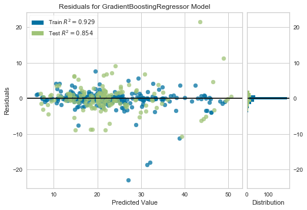

```
None
```

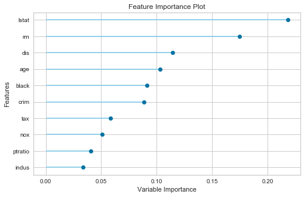

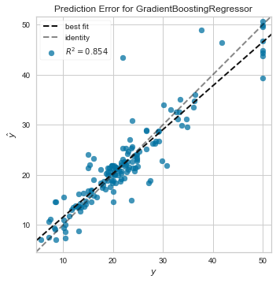

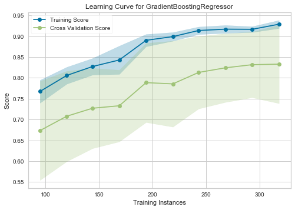

```
None
```

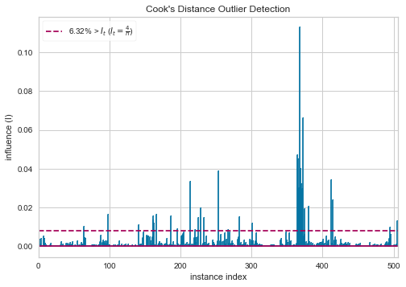

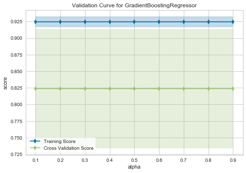

```
None
```

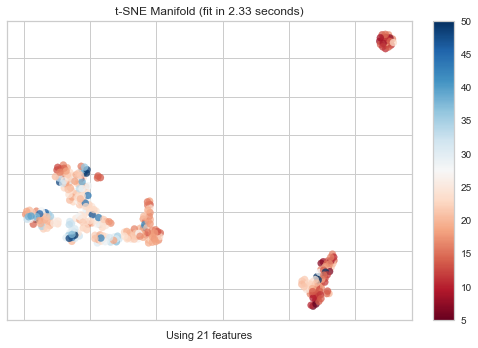

```
None
```

## SHAP (SHapley Additive exPlanations)

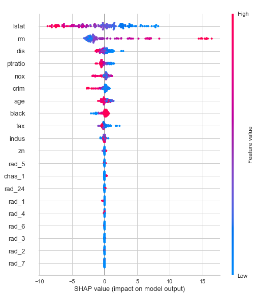

#### Finalized Model for Deployment

Model fit onto the complete dataset including the test/hold-out sample (30% by default). The purpose of this function is to train the model on the complete dataset before it is deployed in production.

```
The accuraccies/metrics of model on test/hold-out sample sets are shown below
```

|  | Model | MAE | MSE | RMSE | R2 | RMSLE | MAPE |
| --- | --- | --- | --- | --- | --- | --- | --- |
| 0 | Gradient Boosting Regressor | 2.3801 | 13.3668 | 3.6561 | 0.8537 | 0.1608 | 0.1217 |

```
Pickling model to lmn/my-regression/Auto select best model/outputs/2020-05-28 21:10:16.756538/
Transformation Pipeline and Model Succesfully Saved
```